# Analyse de l’historique de ventes des livres

Danae Martinez

Dernière mise à jour: 02 juin 2020

# 1 Analyse descriptive de l’historique de ventes

Cette analyse a pour but d’explorer le comportement historique de ventes de livres dans la région de Montréal. Dans un deuxième temps, nous cherchons à identifier l’impact que le Salon du livre a sur les ventes globales.

## 1.1 Montant de ventes annuelles

Le graphique suivant montre le montant vendu par année entre 2010 et 2019 à Montréal.

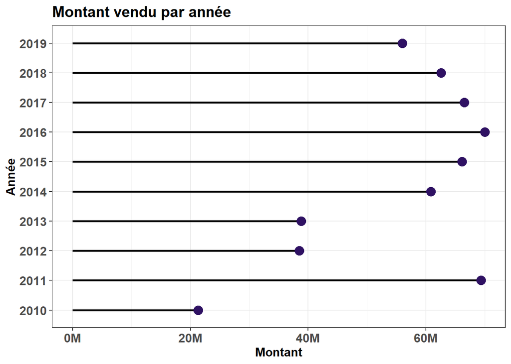

On observe que l’année la plus profitable fut 2016. On observe également que les six dernières années ont été semblables en termes de chiffres annuels. Cependant, il y a une tendance à la baisse depuis 2016. On également remarque que l’année 2011 présente un chiffre de ventes particulièrement haut par rapport aux restes d’années.

## 1.2 Historique du montant de ventes mensuels

Nous voudrions avoir plus d’informations concernant le volume des ventes historiques. Le graphique ci-dessous montre les tendances historiques des ventes mensuelles.

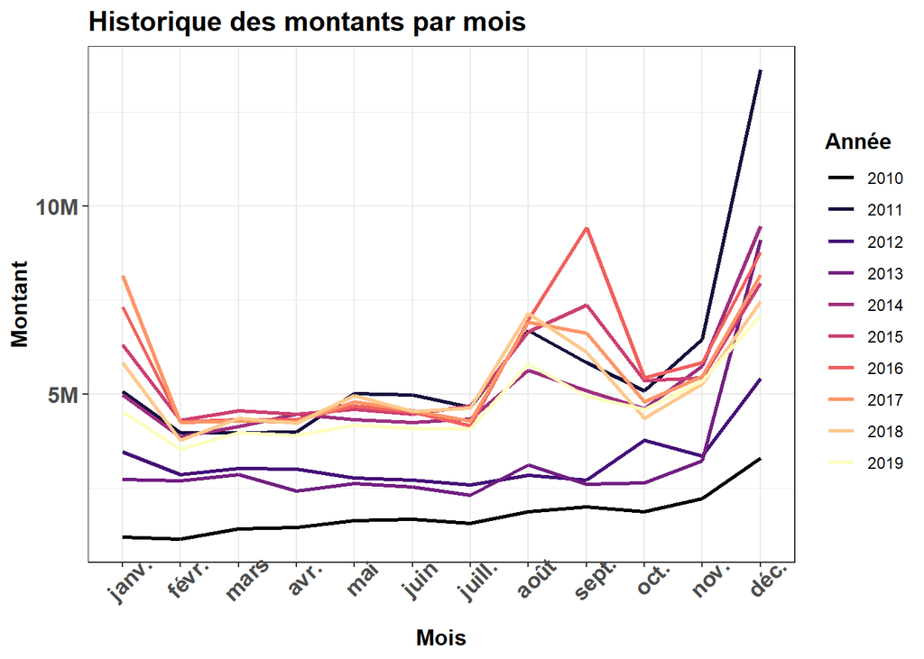

Remarquons que c’est le mois décembre 2011 qui a le record des ventes historiques, suivi de septembre 2016. De façon plus générale, on observe que les trois périodes de pointe sont au mois d’août, au mois de décembre et au mois de janvier.

Le Salon du livre de Montréal a lieu au mois de novembre. Nous aimerions savoir si cet événement a un effet sur les ventes. À première vue il n’est pas évident d’affirmer un effet immédiat, mais on essaie de savoir s’il y a des répercussions sur les semaines suivantes à l’événement.

Les tables suivantes montrent les mois avec plus de ventes pour l’année 2019 dans la région de Montréal.

## 1.3 Mois avec plus de ventes

Montréal 2019

| mois | montant (%) | montant | quantité (%) | quantité |
| --- | --- | --- | --- | --- |
| Décembre | 12.67 | 7096047 | 12.87 | 439675 |
| Août | 10.33 | 5786234 | 10.43 | 356349 |
| Novembre | 9.54 | 5341649 | 9.73 | 332495 |
| Septembre | 8.81 | 4934542 | 7.62 | 260138 |
| Octobre | 8.20 | 4591373 | 8.23 | 281182 |
| Janvier | 8.07 | 4520301 | 6.56 | 224065 |

Les mois avec plus des ventes sont décembre, août, septembre et janvier (période de rentrée scolaire et temps de fêtes), mais on observe que le mois de novembre se trouve parmi les mois avec les plus hautes ventes.

## 1.4 Historique des montants de ventes hedomadaires

Essayons d’aller à un niveau plus détaillé, puis regardons le comportement des ventes par semaine, ici les semaines ont été numérotées de 1 à 52.

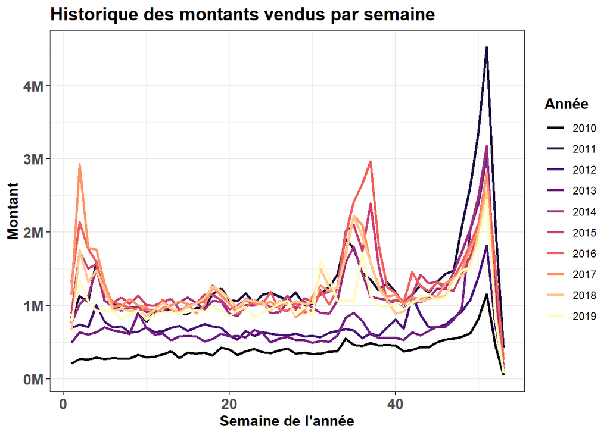

On observe trois périodes de pointe. Est-ce les deux rentrées scolaires et le temps de fêtes?

## 1.5 Historique des montants quotidiens vendus

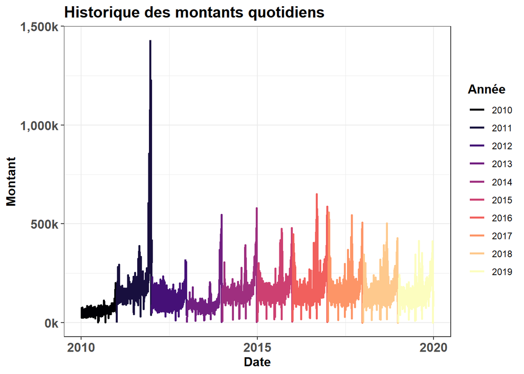

L’année 2011 est une année avec un comportement atypique. À partir 2013 le comportement des séries semble à être plus stable. C’est pour quoi nous allons considérer l’historique à partir 2013 dans les analyses à venir. Remarquons également la présence d’un comportement saisonnière.

### 1.5.1 Historique des ventes quotidiennes au mois de Novembre

Maintenant concentrons-nous à étudier les ventes au mois de novembre à Montréal, soit le mois où le Salon du livre a lieu.

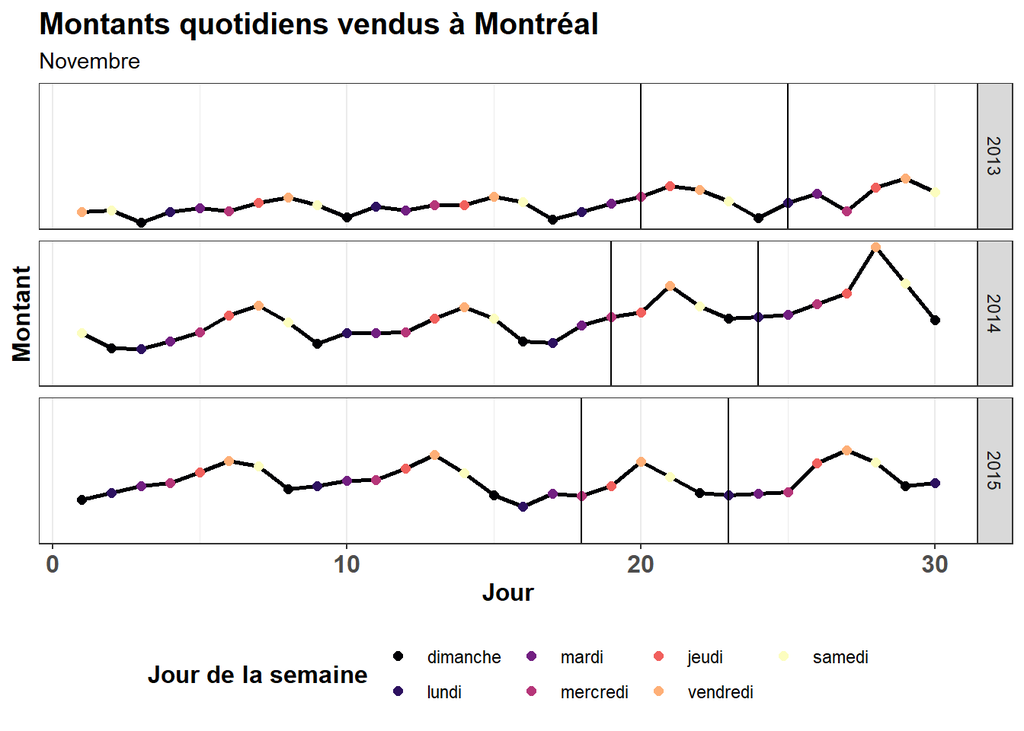

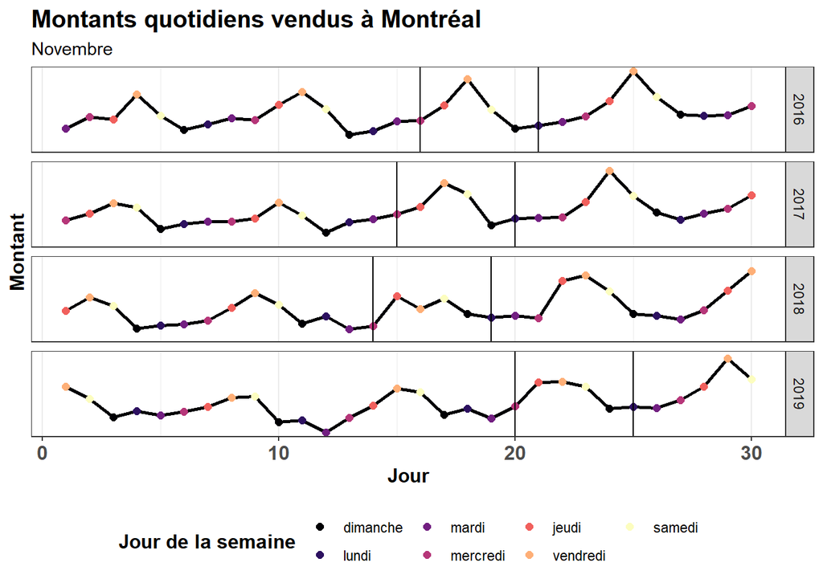

Nous marquons entre bars les semaines où le salon du livre a eu lieu dans pour chaque année. Comme nous pouvons le constater visuelement, il n’ai pas d’effets évidents du au salon du livre.

## 1.6 Conclusion

Avec cette analyse descriptive, on peut difficilement voir les effets du Salon du livre. Nous observons un fort comportement saisonnier au niveau de ventes, qui atteint son maximum aux mois d’août-septembre et décembre-janvier. Une hypothèse liée à ces comportements est l’effet des deux périodes de rentrée scolaire et le temps de fêtes. C’est pour quoi, nous envisageons une analyse des catégories les plus vendues par mois afin de décider quelle est la meilleure façon de contrôler d’un tel effet.